# Techniki Wizualizacji Danych - PD1

Adam Rydelek

15.10.2018

# Wygrane w Lotto

## Miasta, w których najczęściej trafiano wszystkie sześć liczb

Artykuł na stronie wp.pl: https://finanse.wp.pl/gdzie-grac-zeby-wygrac-oto-mapa-polskich-lottomilionerow-6305571623520385a zaciekawił mnie, ponieważ jestem sporadycznym graczem w Lotto. Zamieszczono w nim mapę z ilością trafionych szóstek w największych Polskich miastach. Zliczane były wyniki zarówno z Lotto, jak i Lotto Plus. Jako, że sam gram jedynie w Lotto bez oznaczenia plusem, uznałem, że wykonam wykres dla wygranych tylko w tej kategorii. Dane zostały pobrane ze strony Totalizatora Sportowego: https://www.lotto.pl/lotto/wyniki-i-wygrane/wygrane?page=10&order=wygrana i połączone w jeden spójny data frame.

```r
miasta <- read.csv("lotto_miasta.txt")
wygrane <- read.csv("lotto_wygrane.txt")
wygrane <- wygrane[1]
lotto <- data.frame("Miasta"=miasta, "Wygrana" = wygrane)
colnames(lotto) <- c("Miasto", "Wygrana")
wykres1 <- count(lotto, "Miasto")
wykres1 <- wykres1[order(wykres1$freq, decreasing=TRUE),]
wykres1 <- wykres1[1:15,]
colnames(wykres1) <- c("Miasto", "n")
```

Na podstawie otrzymanych danych stworzyłem wykres, na którym przeanalizowane zostały wszystkie 1095 trafienia szóstek w klasycznej odmianie gry Totalizatora Sportowego i wybrane zostało 15 miast o największej ilości wygranych.

[figure not shown]

```r
ggplot(wykres1, aes(x = reorder(Miasto, -n), y = n, fill=n)) +
  geom_bar(stat = "identity") +
  scale_x_discrete(limits = wykres1$Miasto[1:15]) +
  scale_fill_gradient(low="green", high="darkgreen") +
  theme_bw() +
  theme(axis.text.x=element_text(angle=90,hjust=1,vjust=0.5),
        plot.title = element_text(color="black", size=18, face="bold", hjust=0.5),
        axis.title.x = element_text(color="black", size=14, face="plain"),
        axis.title.y = element_text(color="black", size=14, face="plain")) +
  theme(legend.position="none") +
  xlab("Miasta") + ylab("Liczba trafionych szóstek") +
  ggtitle("Liczba wygranych w Lotto\nw zależności od miasta")
```

## Najszczęśliwsze miasta

Po analizie zamieszczonych w artykule informacji i wykonanego powyżej wykresu doszedłem do wniosku, że nie określa on dobrze, w którym mieście warto grać, ponieważ nie bierze pod uwagę ilości graczy w danym mieście. Jako, że Lotto nie podaje danych na ten temat, wyszedłem z założenia, że liczba graczy Lotto jest proporcjonalna do liczby mieszkańców danego miasta.

Wykorzystałem więc dane ze strony: https://stat.gov.pl/statystyka-regionalna/rankingi-statystyczne/miasta-najwieksze-pod-wzgledem-liczby-ludnosci/ i połączyłem je z wcześniejszą analizą wygranych Lotto.

```r
miasta2 <- read.csv("miasta_nazwy.txt")
mieszkancy <- read.csv("miasta_liczba.txt")

zamieszkanie <- data.frame(miasta2, mieszkancy)
colnames(zamieszkanie) <- c("Miasto", "Mieszkancy")

lacznie <- ddply(lotto, "Miasto", transform, LacznaWygrana=sum(Wygrana))
lacznie <- subset(lacznie, !duplicated(Miasto))
lacznie2 <- lacznie[order(lacznie$LacznaWygrana, decreasing = TRUE),]

wynik <- merge(lacznie2, zamieszkanie, by="Miasto")
wynik <- ddply(wynik, "Miasto", transform, Wskaznik=LacznaWygrana/Mieszkancy)
wykres2 <- wynik[order(wynik$Wskaznik, decreasing = TRUE),]
```

Na ich podstawie wykonałem wykres, który przedstawia średnią wygraną przypadającą na jednego mieszkańca w poszczególnych miastach.

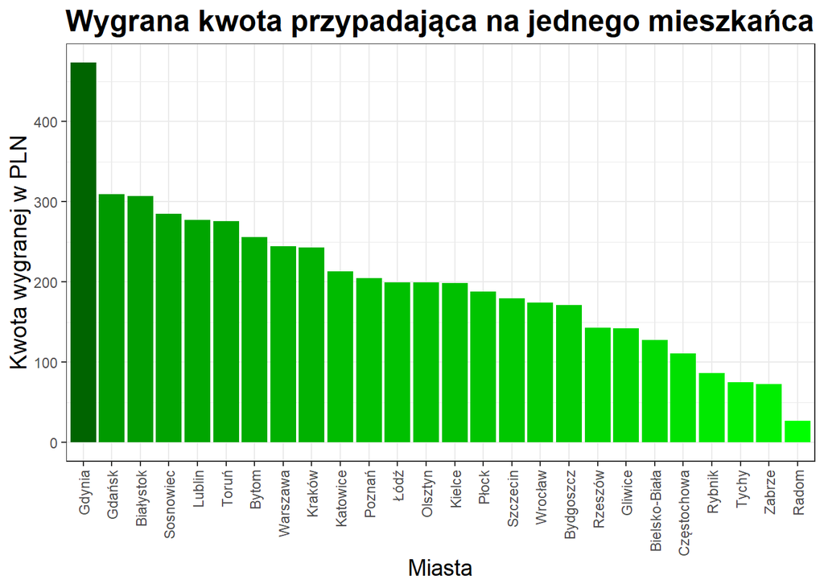

```r
ggplot(wykres2, aes(x = reorder(Miasto, -Wskaznik), y = Wskaznik, fill=Wskaznik)) +
  geom_bar(stat = "identity") +
  theme_bw() +
  scale_x_discrete(limits = wykres2$Miasto) +
  scale_fill_gradient(low="green", high="darkgreen") +
  theme(axis.text.x=element_text(angle=90,hjust=1,vjust=0.5),
        plot.title = element_text(color="black", size=18, face="bold", hjust=0.5),
        axis.title.x = element_text(color="black", size=14, face="plain"),
        axis.title.y = element_text(color="black", size=14, face="plain")) +
  theme(legend.position="none") +
  xlab("Miasta") + ylab("Kwota wygranej w PLN") +
  ggtitle("Wygrana kwota przypadająca na jednego mieszkańca")
```

## Podsumowanie

Na powyższym wykresie można więc zauważyć, że pomimo największej łącznej ilości wygranych w stolicy, po wzięciu pod uwagę ilości mieszkańców, czyli też graczy, spadła aż na 8 miejsce. Z powyższej analizy wynika więc jasny wniosek: aby zwiększyć swoje szanse na wygraną w Lotto, trzeba udać się nad morze, do Gdyni.